# Tematska mapa HNB u digitalnom medijskom prostoru u RH

Lux

20. kolovoza 2025.

### Uvod: O čemu se govori?

Nakon mapiranja ključnih aktera i platformi u prvoj analizi, ovaj izvještaj zaranja dublje u sadržaj digitalnog diskursa o Hrvatskoj narodnoj banci. Koristeći metode obrade prirodnog jezika (NLP) na cjelokupnom korpusu od preko 250.000 medijskih objava, prelazimo s pitanja tko i gdje na pitanje: o čemu se govori?

Cilj je stvoriti “anatomiju diskursa” u tri ključna smjera:

-> Identificirati glavne teme koje oblikuju raspravu o HNB-u.

-> Izmjeriti njihov intenzitet i utjecaj na angažman publike.

-> Otkriti kako se teme međusobno povezuju i kako se njihov fokus mijenja kroz vrijeme.

Aanaliza koristi vođeni pristup tematskom modeliranju, gdje smo na temelju ekonomske i financijske ekspertize definirali ključne tematske kategorije, omogućujući preciznu i interpretativnu klasifikaciju sadržaja.

### Vizualni sažetak korpusa

Prije detaljnije analize,pogledajmo oblak 150 najčešćih, smislenih riječi (imenica, pridjeva i glagola) u cjelokupnom korpusu. Veličina svake riječi proporcionalna je njenoj ukupnoj frekvenciji.

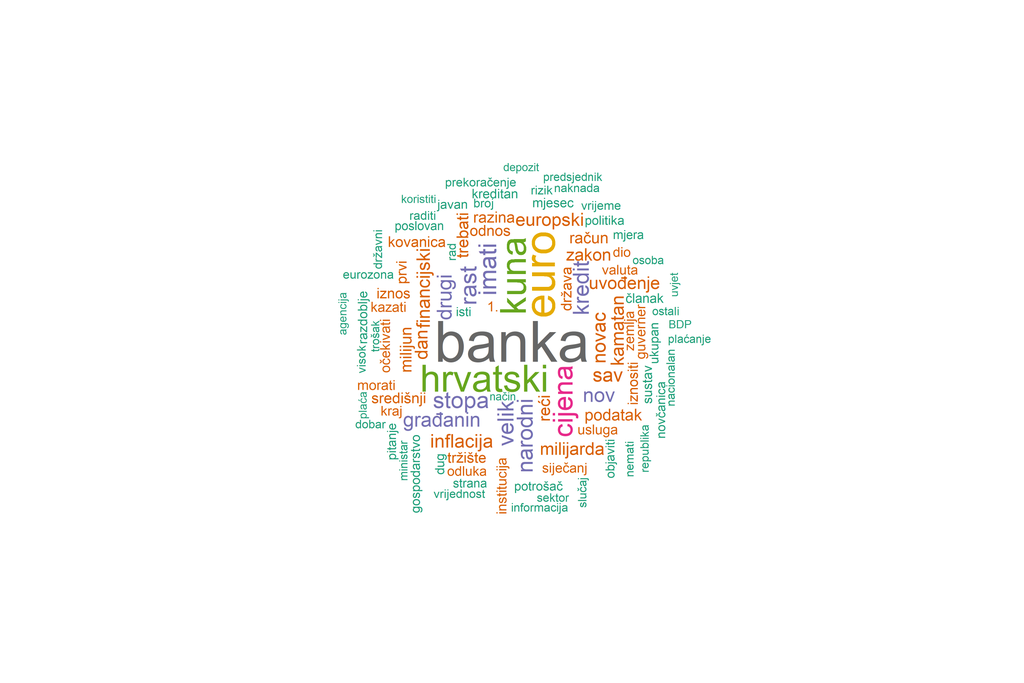

# I.Pregled tematskog pejzaža

Prvi korak je razumjeti opću strukturu diskursa. Koje teme dominiraju, a koje su na marginama? Koliko su te teme centralne za članke u kojima se pojavljuju?

### Dinamika glavnih tema

Analiza udjela svake teme u ukupnom broju spominjanja otkriva stabilnu strukturu, ali i značajne promjene potaknute ključnim događajima. Očekivano, teme vezane za Monetarnu politiku i inflaciju te Financijsku stabilnost čine okosnicu diskursa. Značajan udio zauzima i tema Uvođenja eura, čiji je vrhunac vidljiv tijekom 2022. godine, dok teme vezane za Javnu percepciju i kritike također imaju konstantan i zamjetan udio.

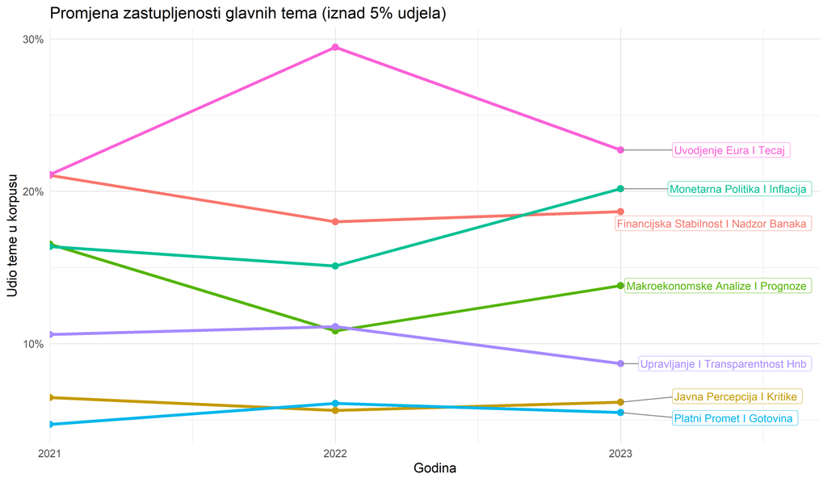

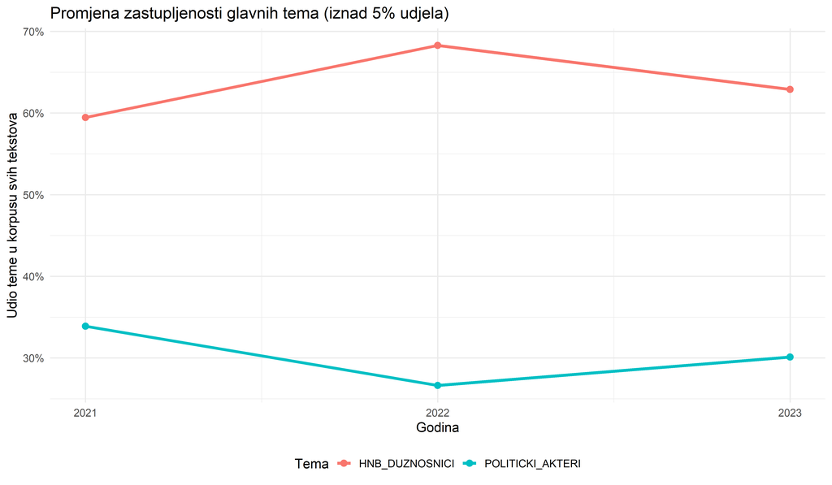

### Intenzitet tema: Što je vijest, a što pozadinski šum?

Nije svako spominjanje teme jednako važno. Ovaj grafikon pokazuje koliko je tema centralna za članak kada se u njemu pojavi. Teme s distribucijom pomaknutom udesno (npr. Monetarna politika) su one koje, kada se pojave, dominiraju člankom i predstavljaju glavnu vijest. Teme s distribucijom bliže lijevoj strani (npr. Međunarodni odnosi) češće se spominju usputno, kao kontekst glavne priče.

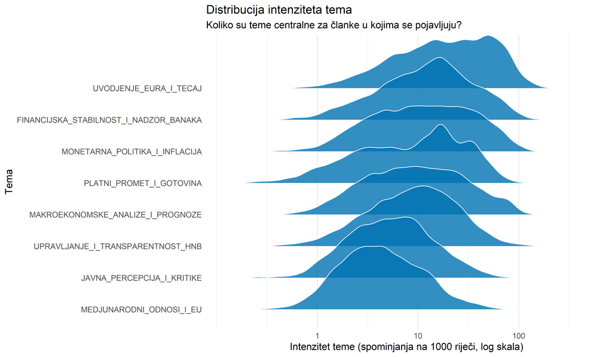

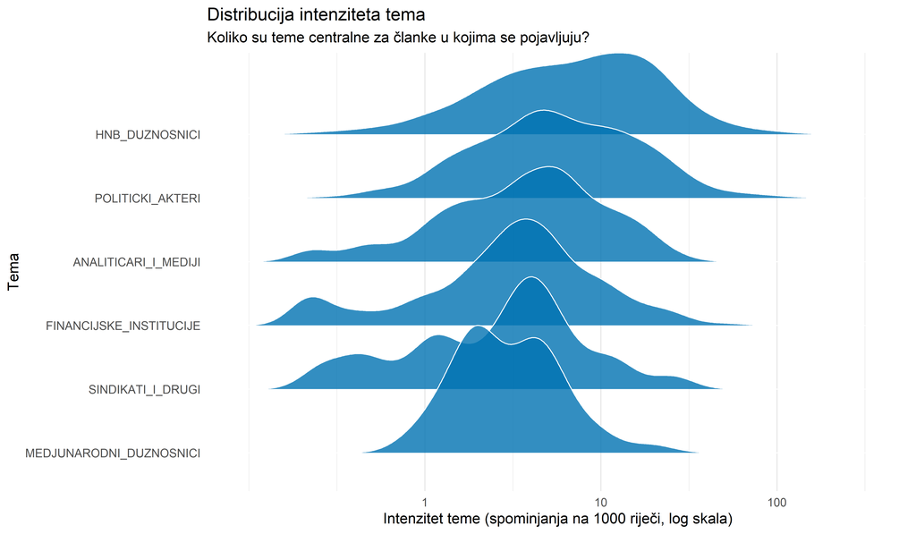

# II.Utjecaj i prijem tema

### Koje teme generiraju najviše interakcija?

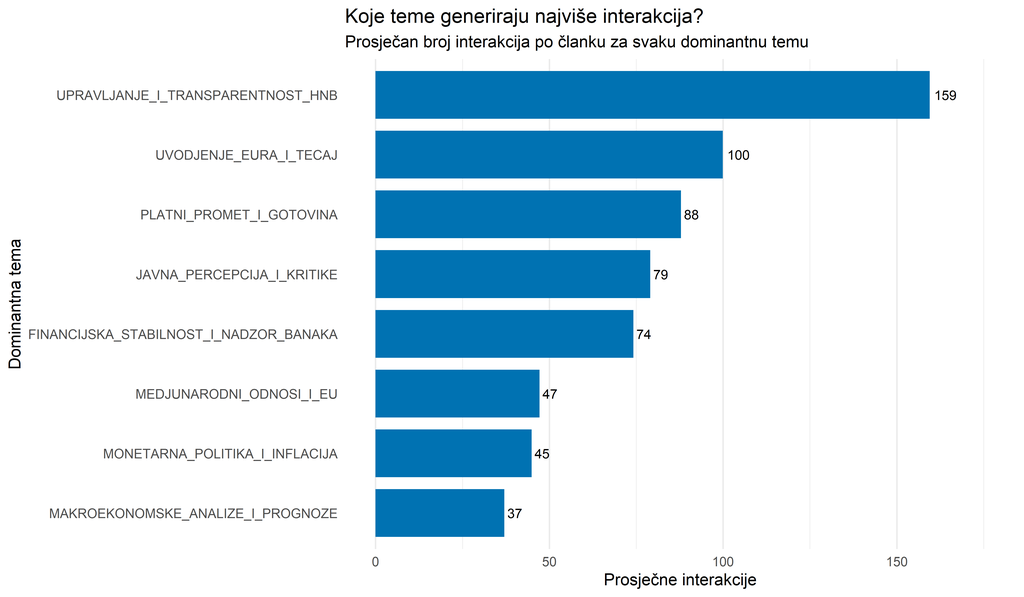

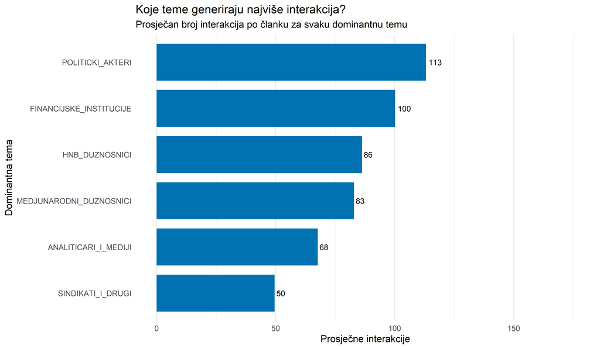

# III.Akteri i narativni okviri

Tko su glavni protagonisti svake teme i kako se teme međusobno povezuju u šire narativne okvire? Ova sekcija spaja tematsku analizu s analizom aktera i mrežnom analizom.

### Glavni akteri unutar svake teme

Svaka tematska “priča” ima svoje glavne likove. Analizom najčešće spominjanih osoba unutar svake dominantne teme, dobivamo uvid u to tko su nositelji narativa. Očekivano, dužnosnici HNB-a dominiraju stručnim temama poput monetarne politike, dok politički akteri preuzimaju glavnu riječ u temama koje se tiču javnih kritika i percepcije.

[figure not shown]

### Mreža narativnih okvira: Kako se teme povezuju?

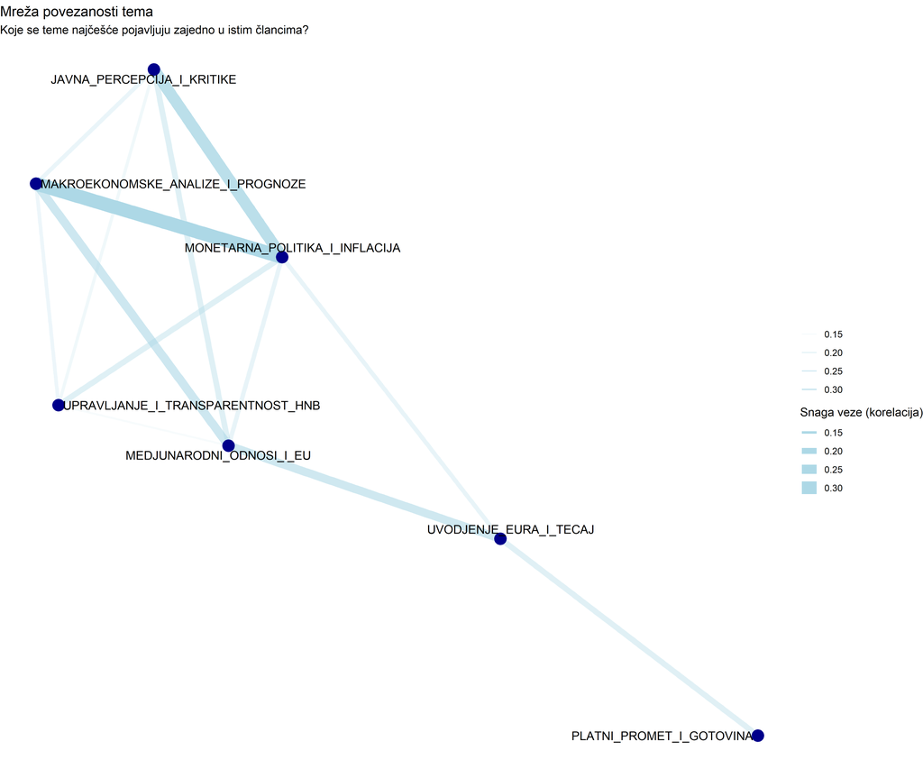